# Data Visualization With R - Bar Plots

2015-10-05

## Introduction

This is the fifth post in the series **Data Visualization With R**. In the previous post we learnt how to build line graphs. In this post, we will visualize categorical data using univariate and bivariate bar plots.

## Bar Plot

A bar plot represents data in rectangular bars. The length of the bars are proportional to the values they represent. Bar plots can be either horizontal or vertical. The X axis of the plot represents the levels or the categories and the Y axis represents the frequency/count of the variable.

## Univariate Bar Plot

A univariate bar plot represents a single categorical variable. The categories in the variable are represented on the X axis and their frequencies on the Y axis. In the below example, the `cyl` variable from the `mtcars` data set is visualized using a bar plot. The categories or levels are `4`, `6` and `8` which represent the number of cylinders in the automobile and are represented on the X axis. The frequency for each type of cylinder is represented by the Y axis.

In R, bar plots can be created using either the `plot()` or `barplot()` function. The input to both the functions are different. In case of the `plot()` function, we can specify the variable but it must be converted to a factor variable. In case of the `barplot()` function, the input must be the count or frequency of the variable. The `table()` function can be used to generate the counts/frequency for a variable. Let us use both the functions to create the bar plot:

#### Using plot function

```r
plot(as.factor(mtcars$cyl))
```

[output not shown]

#### Using barplot function

```r
barplot(table(mtcars$cyl))
```

[output not shown]

```r
cyl_freq <- table(mtcars$cyl)
cyl_freq
```

```
##
##  4  6  8
## 11  7 14
```

#### Horizontal or Vertical

Bar plots can be horizontal or veritcal (which is the default). Use the `horiz` argument in the `barplot()` function to build a horizontal bar plot. As you can see, the axis have been flipped. The Y axis represents the categories and the X axis represents their counts/frequencies.

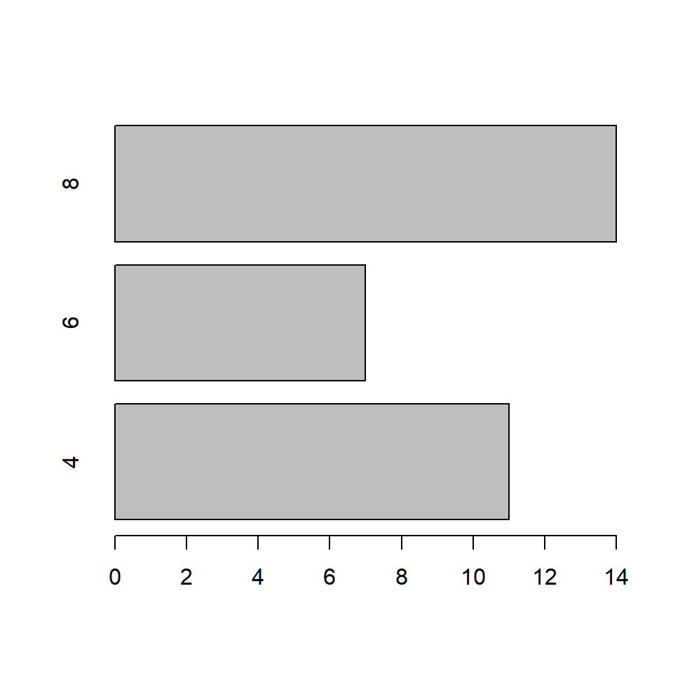

```r
barplot(cyl_freq, horiz = TRUE)
```

#### Bar Width

##### Equal Width

```r
barplot(cyl_freq, width = 2)
```

[output not shown]

##### Different Widths

In the below example, the width of the third bar is twice the width of the other two bars

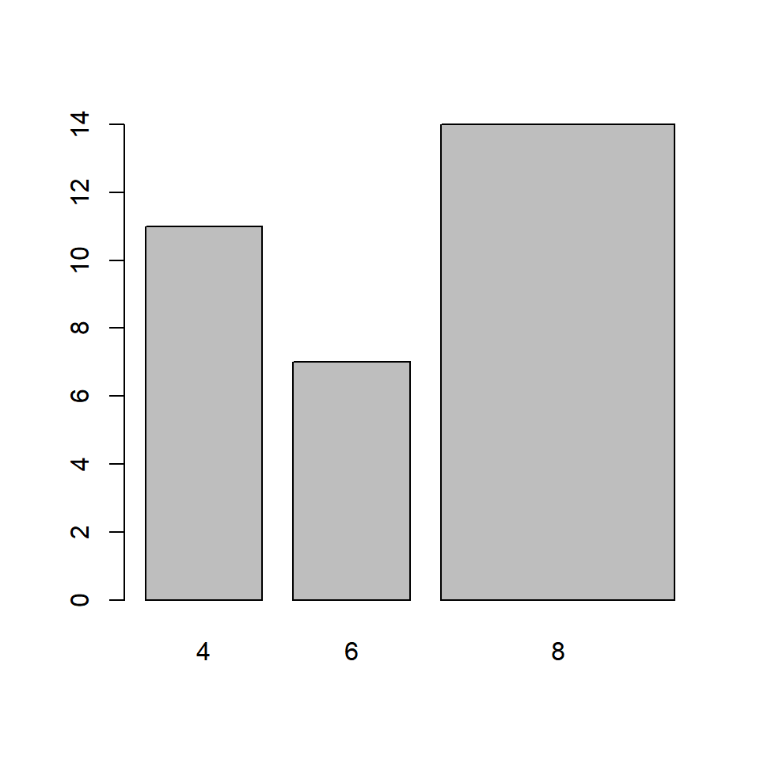

```r
barplot(cyl_freq, width = c(1, 1, 2))
```

In the below example, the width of the second bar is half the width of the other first bar and the third bar is twice the width of the first bar.

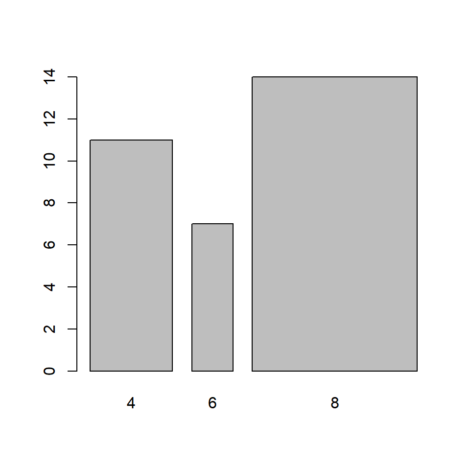

```r
barplot(cyl_freq, width = c(1, 0.5, 2))
```

The space between the bars can be specified in a similar manner but using the `space` argument in the `barplot()` function:

In the below example, the space between the third bar and the second bar is twice the space between first and second bar.

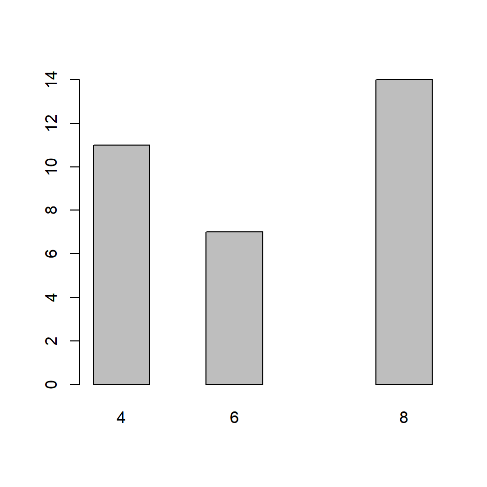

```r
barplot(cyl_freq, space = c(1, 1, 2))
```

#### Labels

It is important to add appropriate labels to the bars in order to communicate properly. In our example, the bars represent automobiles with different number of cylinders. The labels likewise indicate the number of cylinders represented by the bars. In order to demonstrate how to add labels, we will change the labels from numbers to their corresponding words. The `names.arg` argument is used to add labels to the bars in a plot. Below is our example:

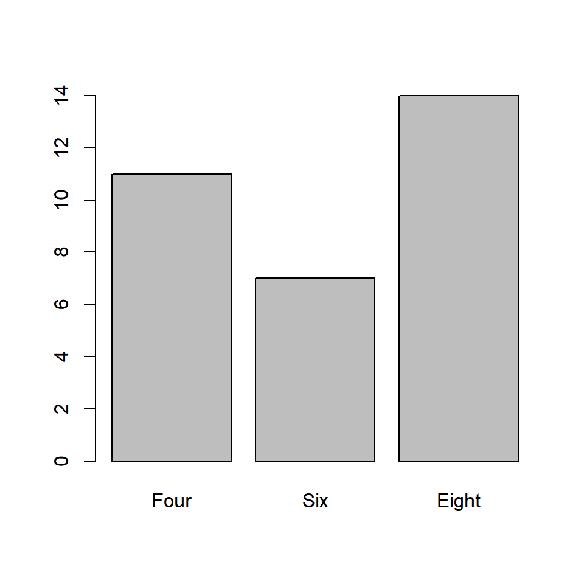

```r
barplot(cyl_freq, names.arg = c('Four', 'Six', 'Eight'))
```

**It is important to specify labels for all the bars in the plot else R will return an error.**

#### Color

Let us add some color to the plots. In a bar plot, we can specify different colors for the bars and their borders. Use the `col` argument to add color to the bars.

###### Same color for all bars

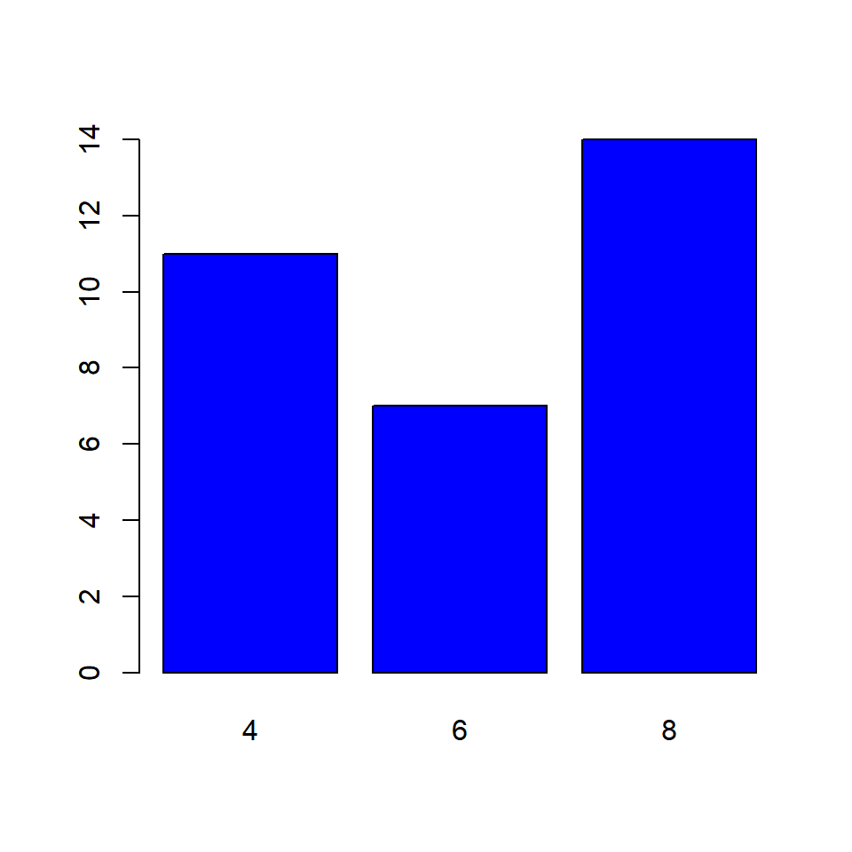

```r
barplot(cyl_freq, col = 'blue')
```

###### Differnt color for the bars

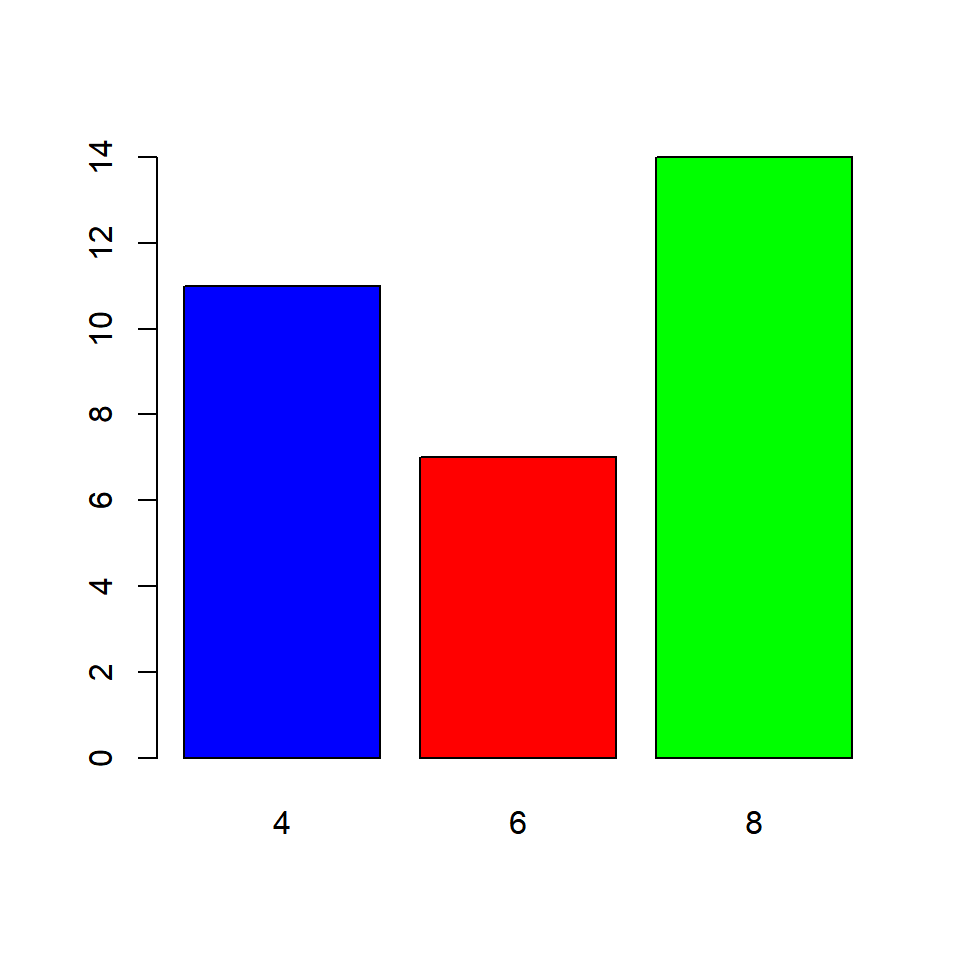

```r
barplot(cyl_freq, col = c('blue', 'red', 'green'))
```

What happens if we do not specify color for all the bars? The colors you specify are recycled.

###### Recycling colors

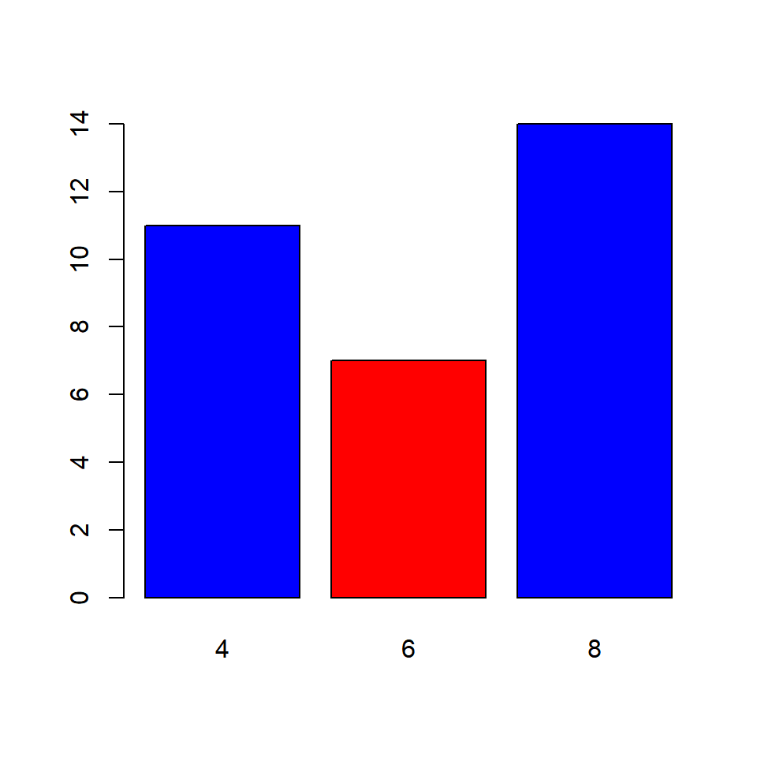

```r
barplot(cyl_freq, col = c('blue', 'red'))
```

The `border` argument specifies the color of the border of the bars. The rules that apply to `col` argument apply here also. Below are the examples:

###### Same color for all bars

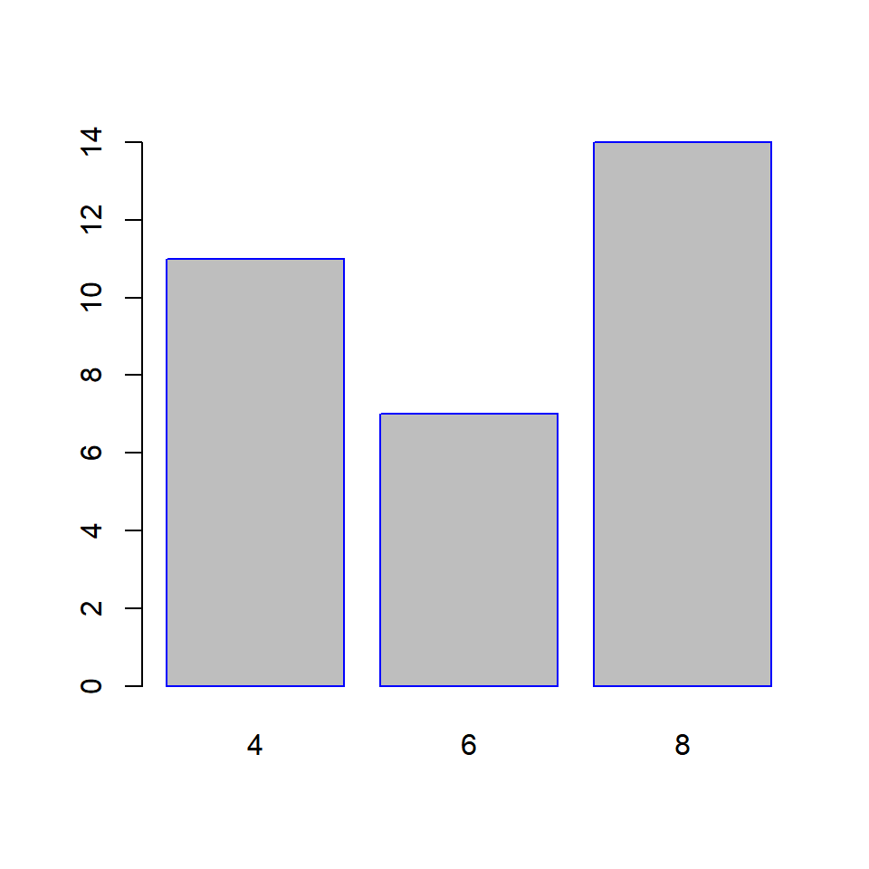

```r
barplot(cyl_freq, border = 'blue')
```

###### Differnt color for the bars

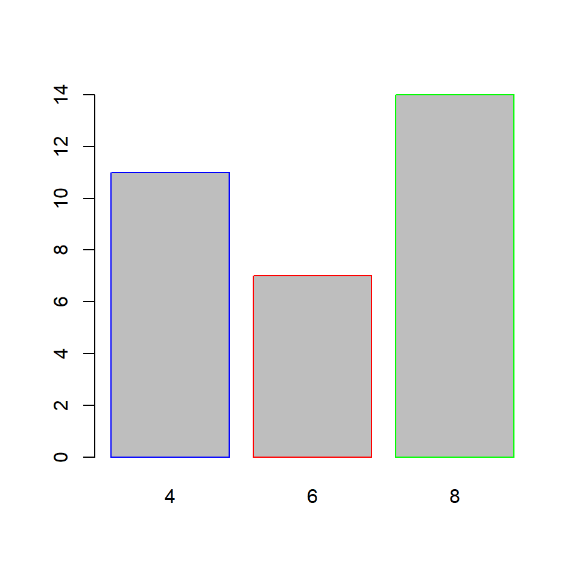

```r
barplot(cyl_freq, border = c('blue', 'red', 'green'))
```

What happens if we do not specify color for all the bars? The colors you specify are recycled.

###### Recycling colors

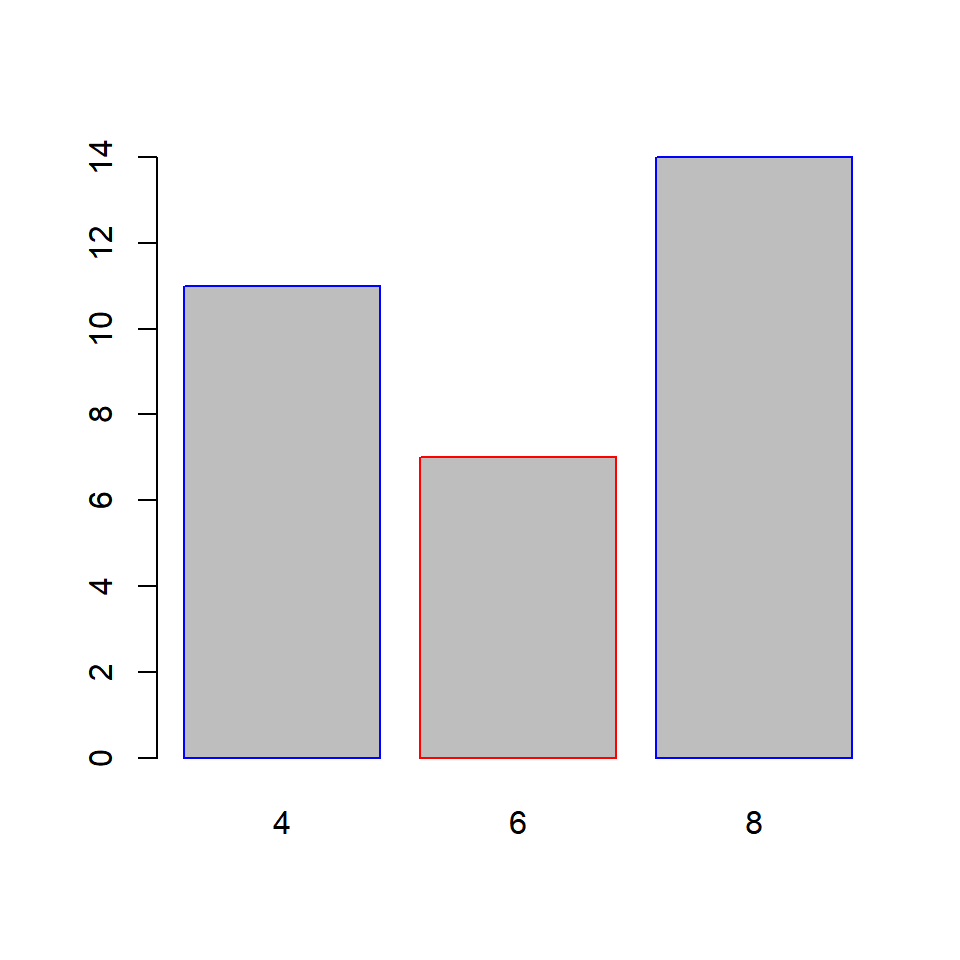

```r
barplot(cyl_freq, border = c('blue', 'red'))
```

#### Axes

In this section, we will learn to

- remove axes from the plot
- specify the line type of the X axes
- offset the Y axes

###### Remove axes

The `axes` argument can be used to retain/remove the axes from the plot. It takes logical values as input and the default is `TRUE`. Set it to `FALSE` to remove the axes from the plot:

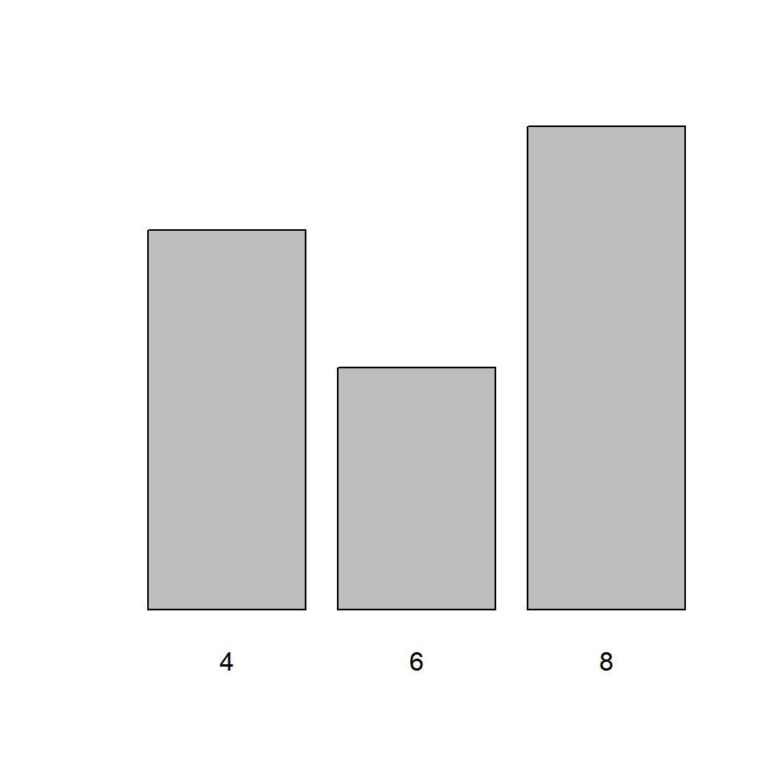

```r
barplot(cyl_freq, axes = FALSE)
```

If we decide to retain the axes, the line type of the X axes can be specified using the `axis.lty` argument. It does not modify the line type of the Y axes and it will not work if the `axes` argument is set to `FALSE`.

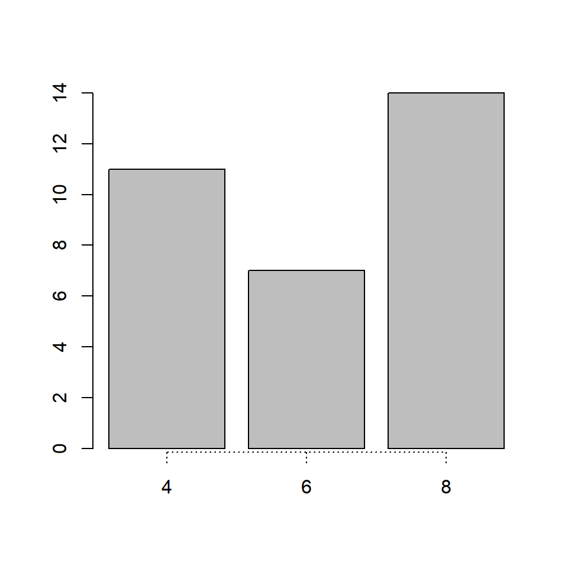

```r
barplot(cyl_freq, axis.lty = 3)
```

Though we cannot modify the line type of the Y axes, we can offset it using the `offset` argument. In the below example, we will offset the Y axes and you can observe that the minimum value of the Y axes is now 5 instead of 0.

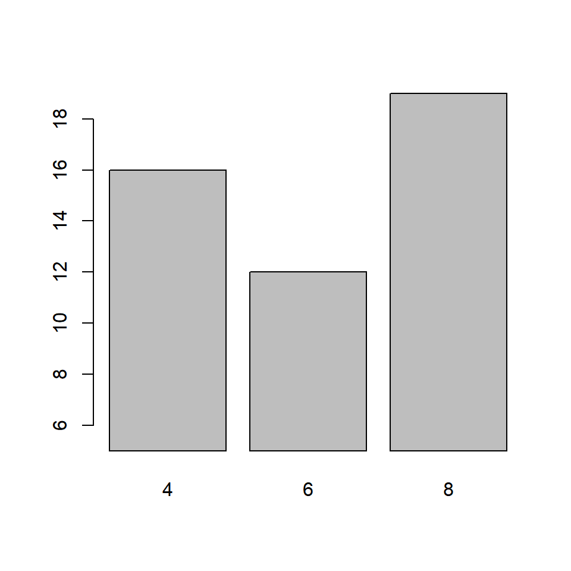

```r
barplot(cyl_freq, offset = 5)
```

You can similarly modify the range of the Y axes using the `ylim` argument. Although in case of bar plots, modifying the range of the plot may not be very useful.

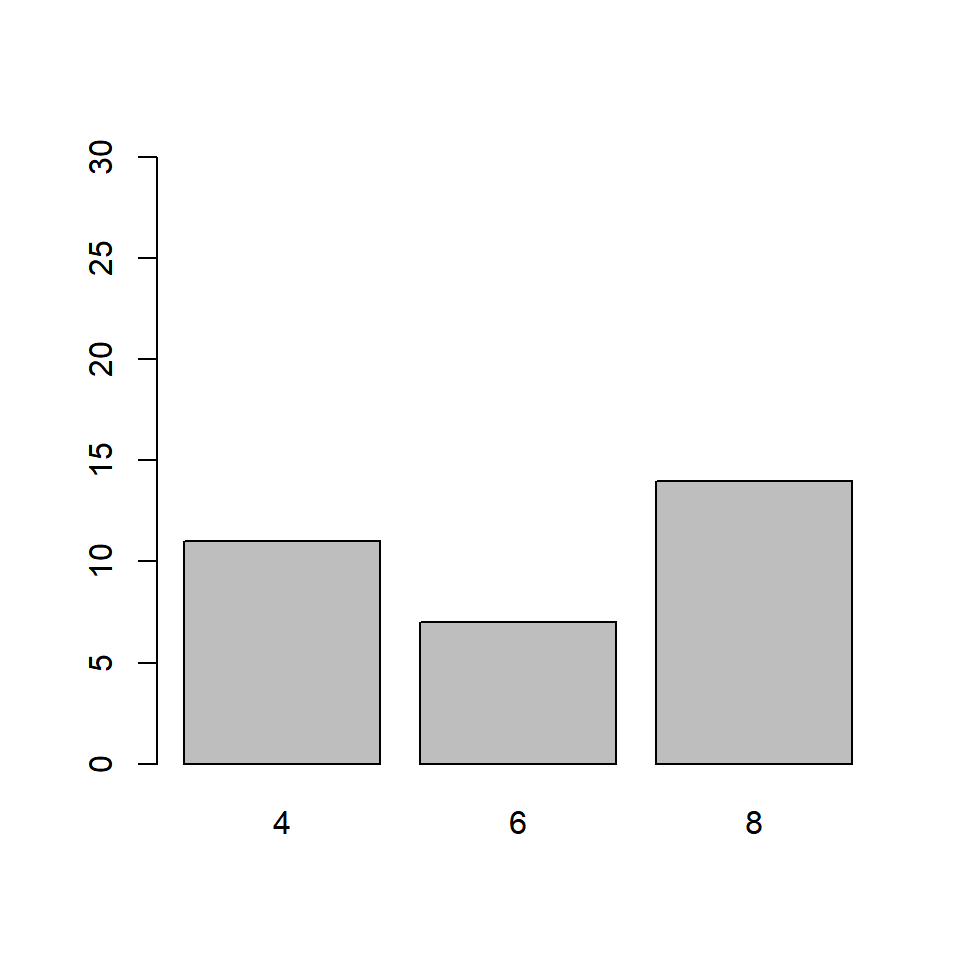

```r
barplot(cyl_freq, ylim = c(0, 30))
```

Let us quickly revise what we have learnt so far in this post and build a bar plot for visualizing the `cyl` variable in the `mtcars` data set:

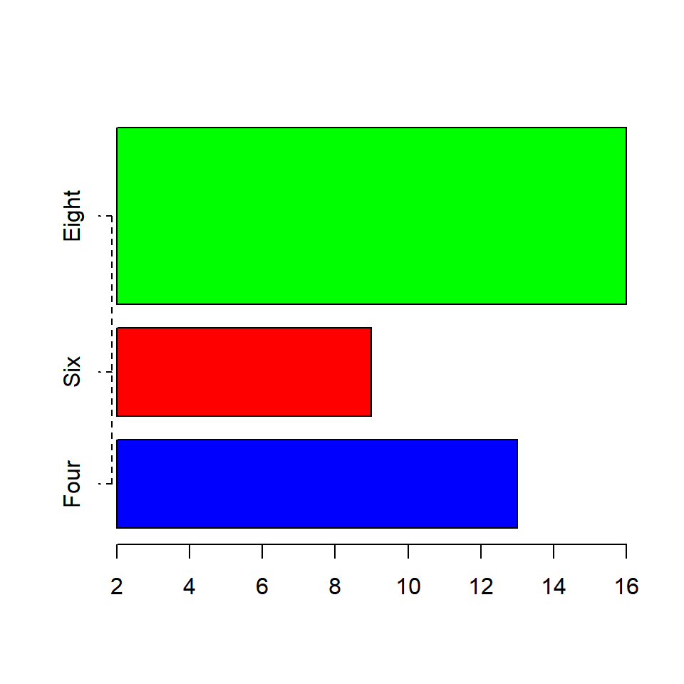

```r
barplot(cyl_freq, col = c('blue', 'red', 'green'),
        horiz = TRUE, width = c(1, 1, 2),
        names.arg = c('Four', 'Six', 'Eight'),
        axis.lty = 2, offset = 2)
```

Well the plot looks good but for someone who does not know the underlying data, it will diffficult to understand what is being communicated. Let us add a title and labels for the axes.

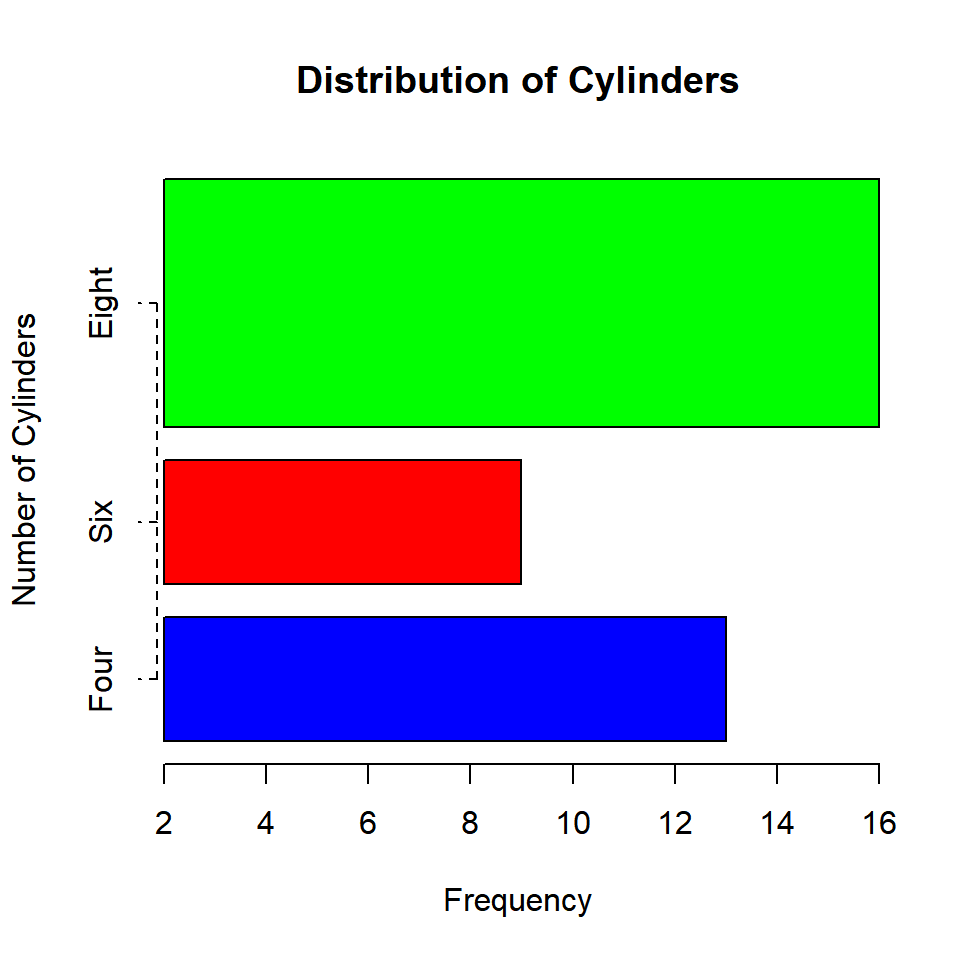

```r
barplot(cyl_freq, col = c('blue', 'red', 'green'),
        horiz = TRUE, width = c(1, 1, 2),
        names.arg = c('Four', 'Six', 'Eight'),
        axis.lty = 2, offset = 2)
title(main = 'Distribution of Cylinders',
      xlab = 'Frequency', ylab = 'Number of Cylinders')
```

## Bivariate Bar Plots

A bivariate bar plot represents the cross table or two way table of categorical variables. They are of two types:

- Stacked Bar Plots
- Grouped Bar Plots

Before we look at bivariate bar plots, let us create a two way table of `cyl` (number of cylinders) and `gear` (number of gears) using the `table()` function:

```r
table(mtcars$gear)
```

```
##
##  3  4  5
## 15 12  5
```

```r
cyl_gear <- table(mtcars$cyl, mtcars$gear)
cyl_gear
```

```
##
##      3  4  5
##   4  1  8  2
##   6  2  4  1
##   8 12  0  2
```

The number of gears is represented by the columns in the table and the numbe rof cylinders is represented by the rows.

#### Stacked Bar Plot

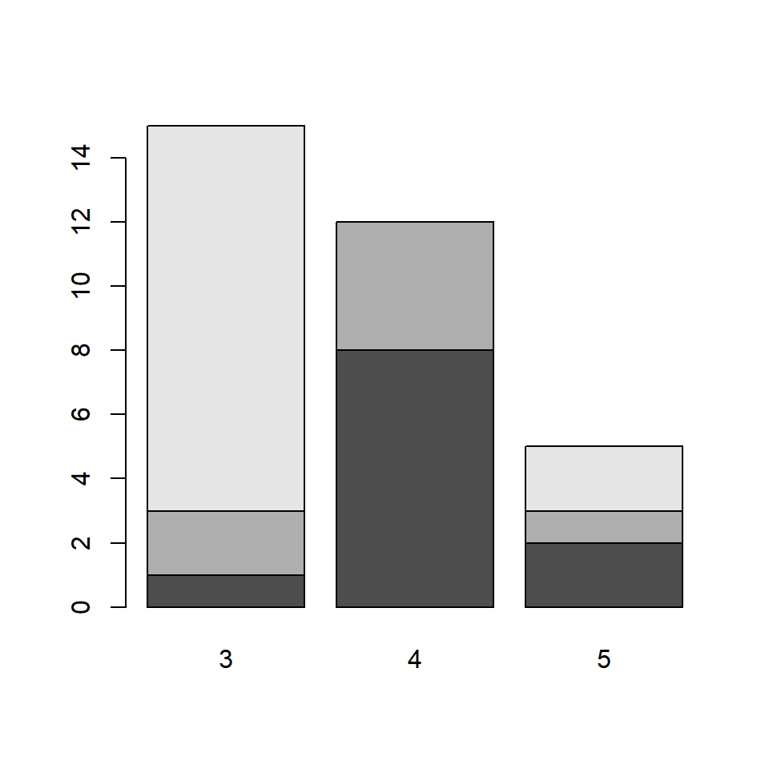

```r
barplot(cyl_gear)
```

The bars in the plot represent the distribution of `cyl` for each level of category of the `gear` variable. The first bar represents the distribution of cylinders for automobiles with 3 gears. From the two way table we saw earlier, the columns are the bars. The rows are represented by different sections of the bar. Let us add some colors to the plot as the default colors of the plot are not very intuitive. It will also allow us to clearly examine the distribution of `cyl` for the different levels of `gear`.

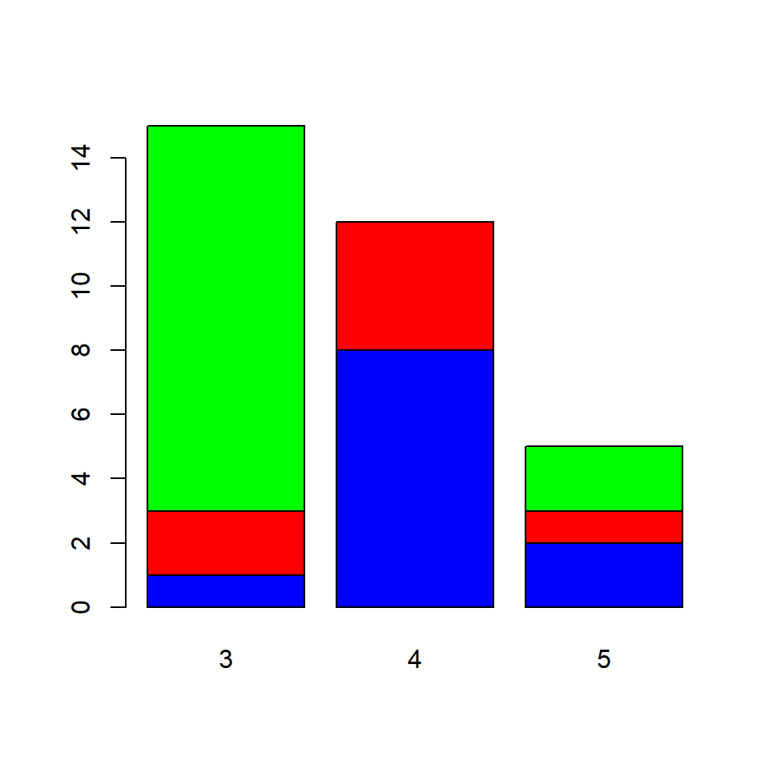

```r
barplot(cyl_gear, col = c('blue', 'red', 'green'))
```

We need to convey the above information in some way and will do that using the `legend.text` argument. It takes logical values as inputs and the default values is `FALSE`. It adds a legend to the plot when it is set to `TRUE`. In the next example, we add a legend as well as other relevant information such as title and axis labels.

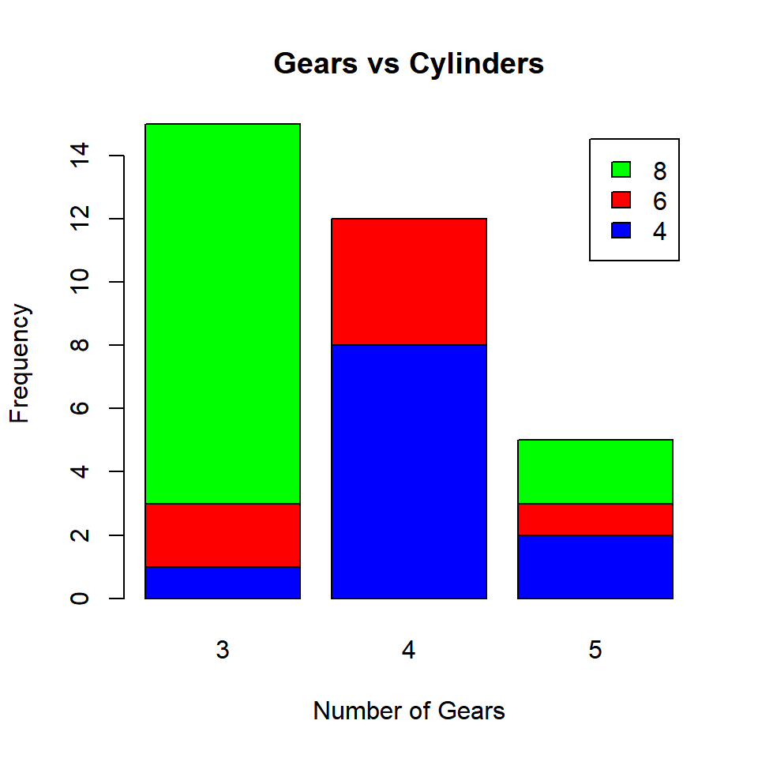

```r
barplot(cyl_gear, col = c('blue', 'red', 'green'),
        main = 'Gears vs Cylinders', legend.text = TRUE,
        xlab = 'Number of Gears', ylab = 'Frequency')
```

#### Grouped Bar Plot

A grouped bar plot represents the same data as the stacked bar plot but instead of being stacked, the bars are now grouped and placed besides each other.

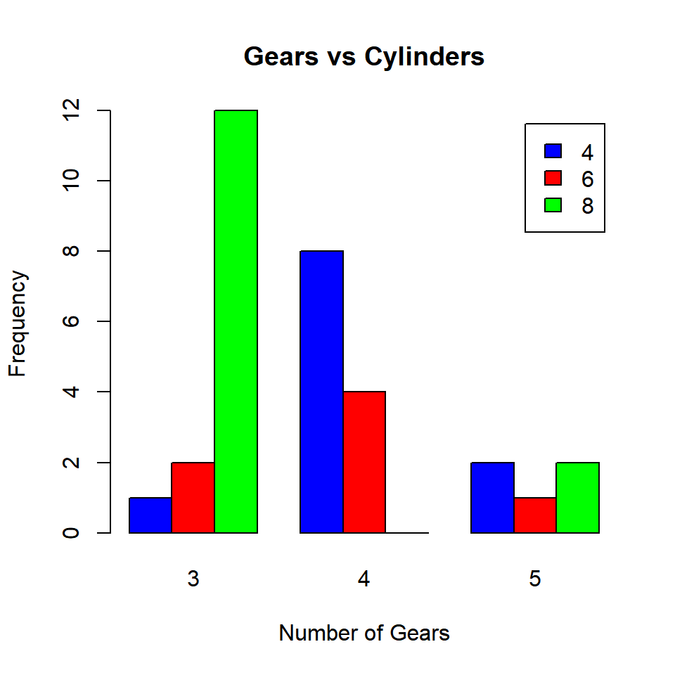

```r
barplot(cyl_gear, col = c('blue', 'red', 'green'),
        beside = TRUE, legend.text = TRUE,
        main = 'Gears vs Cylinders',
        xlab = 'Number of Gears', ylab = 'Frequency')
```

The `beside` argument in `barplot()` function is set to `TRUE` to build grouped bar plots. It takes logical values as inputs and the default values is FALSE. As you can observe from the plot, the bars are placed besides each other instead of being stacked.

## Summary

In this post, we learnt how to build

- univariate bar plots
- bivariate bar plots

and explored various arguments within the `barplot()` function such as

- `horiz`
- `col`
- `border`
- `space`
- `width`
- `names.arg`
- `offset`
- `legend.text`

to modify and enhance the appearance of the plot. In the next post, we will learn how to build box plots.